# Return Analysis

An illustration of the Data Pipeline with R and Rmarkdown

EPFL Extension School

# 1 Single company analysis

For this single company analysis, we’ll be focusing on the company Tesla

To narrow our focus, we will restrain our analysis to a given timeframe. Let’s focus on the performance of the stocks of Tesla from the beginning of the pandemic (March 11 2020) until now.

The data is stored in an Excel (`.xlsx`) sheet. We have imported it using the `read_xlsx()` function from `{readxl}` to import it

We can explore the data by printing its first 6 lines:

| symbol | date | open | high | low | close | volume | adjusted |
| --- | --- | --- | --- | --- | --- | --- | --- |
| TSLA | 2013-01-02 | 2.333333 | 2.363333 | 2.314000 | 2.357333 | 17922000 | 2.357333 |
| TSLA | 2013-01-03 | 2.345333 | 2.363333 | 2.316667 | 2.318000 | 11130000 | 2.318000 |
| TSLA | 2013-01-04 | 2.320000 | 2.320000 | 2.261333 | 2.293333 | 10110000 | 2.293333 |
| TSLA | 2013-01-07 | 2.320000 | 2.320000 | 2.260000 | 2.289333 | 6630000 | 2.289333 |
| TSLA | 2013-01-08 | 2.300000 | 2.300000 | 2.207333 | 2.245333 | 19260000 | 2.245333 |
| TSLA | 2013-01-09 | 2.267333 | 2.279333 | 2.226667 | 2.242667 | 10470000 | 2.242667 |

## 1.1 Understanding the data

### 1.1.1 Tidying and transforming

Since we are interested in the performance of the stock from the beginning of the pandemic, we can use the function `filter()` from `{dplyr}`.

### 1.1.2 Visualising the data

With this data and the functions in `ggplot()`, we can create a first visualisation of the closing stock price. We set the dates on the `x` axis and the `close` price in the `y` axis.

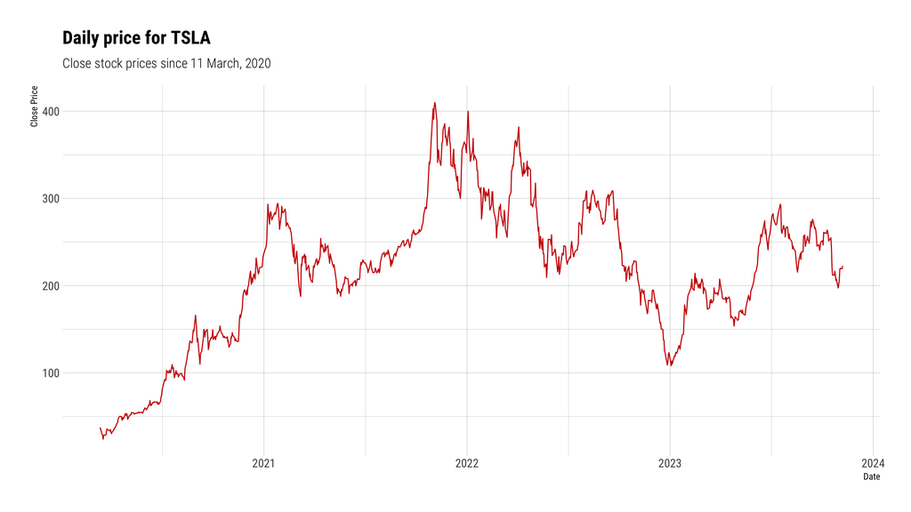

### 1.1.3 The loop of Understanding:

The visualisation offers a first clance. We can transform again to ask the questions on the returns. We use the function `mutate()`, alongside `lag(0` to create a column with the daily (log) returns.

We can construct a visualisation with this. Additionally, we can add layers to our visualisation to decorate it at will.

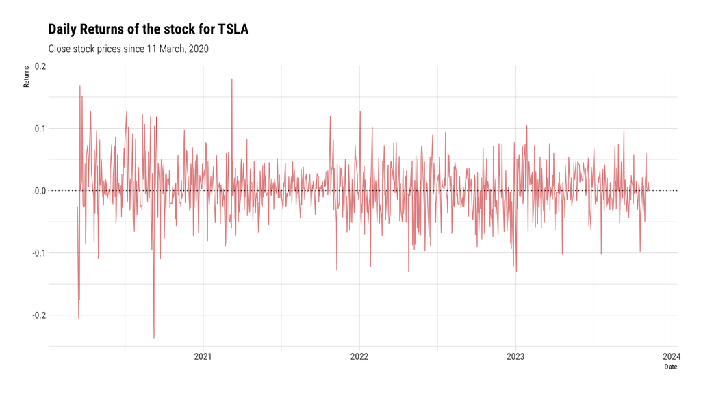

We can obtain a summary table for some summary statisics with `summarise()`

| Average Return | Average Risk (SD) |
| --- | --- |
| 0.001933085 | 0.04184568 |

And, seeing that the visualisation shows periods of high volatility in the year 2020, we can compute yearly measures of risk and volatility:

| year | Average Return | Average Risk (SD) |
| --- | --- | --- |
| 2020 | 0.009017976 | 0.05383673 |
| 2021 | 0.001602517 | 0.03415218 |
| 2022 | -0.004186147 | 0.04226906 |
| 2023 | 0.002741982 | 0.03519762 |

# 2 Analysis for all companies

## 2.1 Plotting the stock price

Here’s a chart with the closing stock prices for all companies.

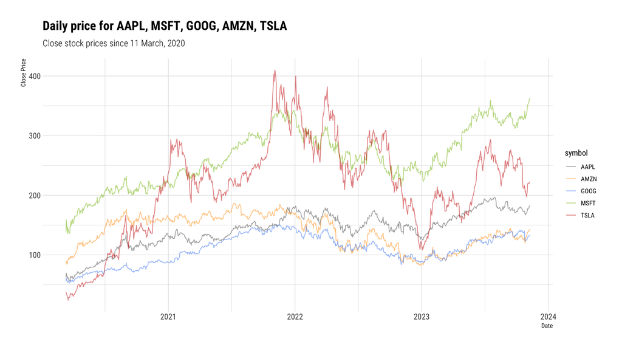

From the plot, we can gather that TESLA INC (TSLA) has the clearest trend of growth. However this seems to be associated with a very high risk, as it the prices look very variable over the years.

## 2.2 Returns by company

To gain more insight in what pertains returns of these stocks, we can compute the returns for all companies. For easier visualisation, we can separate them according to the company.

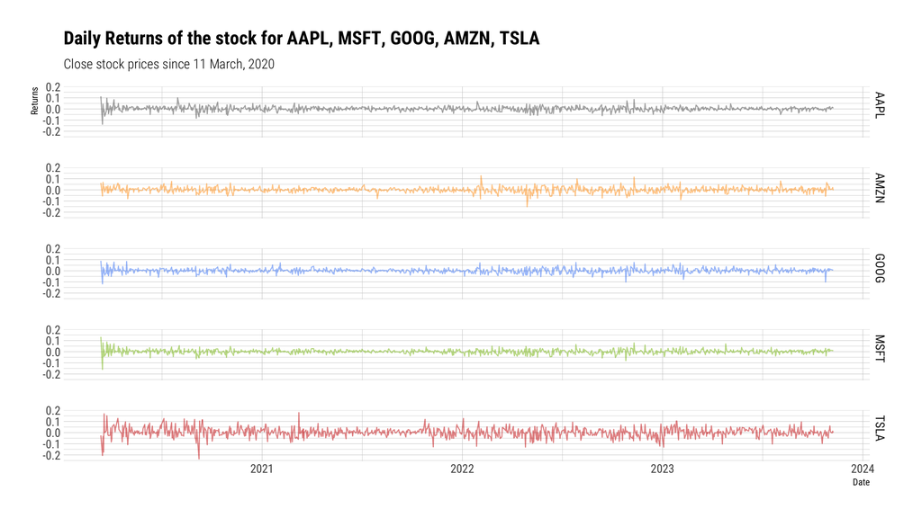

## 2.3 Average returns and Risk over the years

Table 1 : Average return (in percentage points)

| symbol | 2020 | 2021 | 2022 | 2023 |
| --- | --- | --- | --- | --- |
| AAPL | 0.3725 | 0.1156 | -0.1244 | 0.1590 |
| AMZN | 0.3255 | 0.0093 | -0.2731 | 0.2445 |
| GOOG | 0.2215 | 0.1991 | -0.1948 | 0.1892 |
| MSFT | 0.2302 | 0.1641 | -0.1347 | 0.1931 |
| TSLA | 0.9018 | 0.1603 | -0.4186 | 0.2742 |

Table 2 : Risk (SD in percentage points)

| symbol | 2020 | 2021 | 2022 | 2023 |
| --- | --- | --- | --- | --- |
| AAPL | 2.8270 | 1.5809 | 2.2447 | 1.3338 |
| AMZN | 2.3747 | 1.5217 | 3.1579 | 2.1826 |
| GOOG | 2.3415 | 1.4864 | 2.4442 | 1.9999 |
| MSFT | 2.6780 | 1.3246 | 2.2270 | 1.6414 |
| TSLA | 5.3837 | 3.4152 | 4.2269 | 3.5198 |